# Практика 11 · Наївний Баєс

> 📖 **Теорія:** відкрий `lecture.html` у цій же теці. 📝 **Домашнє:** `homework.html` · 🧪 **Тест:** `quiz.html`

У лекції наївний Баєс показано ззовні: сітка зі ста оголошень, смужки внесків, повзунок згладжування. Тут ми зберемо його з нуля — так, щоб не лишилось жодного місця, де «бібліотека щось порахувала сама».

**Що зробимо:**

1. Зберемо той самий архів зі ста оголошень про вживані телефони, що в лекції
2. Порахуємо теорему Баєса на одному слові й повторимо пастку з апріорною ймовірністю
3. Перевіримо на даних, наскільки хибне «наївне» припущення про незалежність
4. Класифікуємо конкретне оголошення покроково й звіримо кожне число з `MultinomialNB`
5. Вимкнемо згладжування Лапласа й побачимо, як усе ламається
6. Перейдемо на логарифми й переконаємось, що добуток без них провалюється в нуль
7. Наостанок візьмемо числові ознаки, запустимо `GaussianNB` і порівняємо його з kNN із теми 15 на тих самих даних

## 1. Архів: сто оголошень і сім слів

Той самий архів, що в лекції: 100 оголошень, з них 28 виявились приманками. Про кожне відомо, які з семи слів словника є в його тексті.

Щоб числа тут збігалися з лекцією до останньої цифри, ми не кидаємо монетку, а ставимо слова в наперед визначені оголошення. Функція `поставити_слово` робить рівно це.

```python
import numpy as np

СЛОВА = ["терміново", "передоплата", "новий", "чек", "гарантія", "дешево", "торг"]

# рядок — оголошення, колонка — слово; 1 означає «слово є в тексті»
слова_в_оголошеннях = np.zeros((100, 7), dtype=int)

# перші 28 рядків — шахрайські, решта 72 — чесні
шахрайство = np.zeros(100, dtype=int)
шахрайство[:28] = 1


def поставити_слово(слово, від_рядка, до_рядка):
    '''Ставить слово в діапазон оголошень включно з обома краями.

    Явні діапазони потрібні, щоб архів збігся з таблицею лекції не лише за
    кількостями, а й за тим, які слова стоять в одному оголошенні разом.
    '''
    номер = СЛОВА.index(слово)
    слова_в_оголошеннях[від_рядка:до_рядка + 1, номер] = 1


# шахрайські оголошення (рядки 0-27)
поставити_слово("передоплата", 0, 20)
поставити_слово("терміново", 4, 22)
поставити_слово("новий", 0, 7)
поставити_слово("гарантія", 25, 27)
поставити_слово("дешево", 6, 21)
поставити_слово("торг", 21, 27)
# «чек» у шахрайських не ставимо жодного разу — приманки не пропонують чек

# чесні оголошення (рядки 28-99)
поставити_слово("терміново", 28, 36)
поставити_слово("передоплата", 34, 39)
поставити_слово("новий", 28, 55)
поставити_слово("чек", 56, 86)
поставити_слово("гарантія", 60, 85)
поставити_слово("дешево", 43, 53)
поставити_слово("торг", 67, 99)

print("оголошень усього:", len(шахрайство))
print("шахрайських:", int(шахрайство.sum()), "· чесних:", int((1 - шахрайство).sum()))
```

```
оголошень усього: 100
шахрайських: 28 · чесних: 72
```

Тепер порахуємо, скільки разів кожне слово трапилось у кожному класі. Ці два рядки чисел — і є вся «навчена» частина мультиноміального наївного Баєса.

```python
import pandas as pd

лічильники_шахр = слова_в_оголошеннях[шахрайство == 1].sum(axis=0)
лічильники_чесн = слова_в_оголошеннях[шахрайство == 0].sum(axis=0)

таблиця = pd.DataFrame({
    "у шахрайських": лічильники_шахр,
    "у чесних": лічильники_чесн,
}, index=СЛОВА)
таблиця.loc["РАЗОМ"] = [лічильники_шахр.sum(), лічильники_чесн.sum()]
print(таблиця)
```

```
             у шахрайських  у чесних
терміново               19         9
передоплата             21         6
новий                    8        28
чек                      0        31
гарантія                 3        26
дешево                  16        11
торг                     7        33
РАЗОМ                   74       144
```

Числа мають збігтися з таблицею лекції. Перевіримо це не очима, а `assert` — щоб зошит сам ловив розходження, якщо колись хтось змінить генерацію архіву.

```python
# ті самі числа, що надруковані в розділі 4 лекції
assert list(лічильники_шахр) == [19, 21, 8, 0, 3, 16, 7], "архів розійшовся з лекцією!"
assert list(лічильники_чесн) == [9, 6, 28, 31, 26, 11, 33], "архів розійшовся з лекцією!"
print("✅ архів збігається з таблицею лекції")
```

```
✅ архів збігається з таблицею лекції
```

## 2. Теорема Баєса на одному слові

Питання лекції: в оголошенні є слово «передоплата» — яка ймовірність, що воно шахрайське? Порахуємо двома способами: спершу просто поділивши кількості, потім за формулою. Числа мають зійтися.

```python
є_передоплата = слова_в_оголошеннях[:, СЛОВА.index("передоплата")] == 1

шахрайських_зі_словом = int(шахрайство[є_передоплата].sum())
усього_зі_словом = int(є_передоплата.sum())

print("оголошень зі словом «передоплата»:", усього_зі_словом)
print("з них шахрайських:", шахрайських_зі_словом)
print("P(шахрайство | слово) =", шахрайських_зі_словом, "/", усього_зі_словом,
      "=", round(шахрайських_зі_словом / усього_зі_словом, 4))
```

```
оголошень зі словом «передоплата»: 27
з них шахрайських: 21
P(шахрайство | слово) = 21 / 27 = 0.7778
```

```python
# те саме за формулою Баєса: P(A|B) = P(B|A) * P(A) / P(B)
апріорна_шахрайство = шахрайство.mean()                       # частка шахраїв до будь-яких свідчень
правдоподібність = є_передоплата[шахрайство == 1].mean()      # як часто шахраї пишуть це слово
ймовірність_слова = є_передоплата.mean()                      # як часто слово трапляється взагалі

за_формулою = правдоподібність * апріорна_шахрайство / ймовірність_слова

print(f"P(шахрайство)        = {апріорна_шахрайство:.4f}")
print(f"P(слово | шахрайство) = {правдоподібність:.4f}")
print(f"P(слово)             = {ймовірність_слова:.4f}")
print(f"P(шахрайство | слово) = {за_формулою:.4f}")

assert np.isclose(за_формулою, шахрайських_зі_словом / усього_зі_словом)
print("✅ формула дає рівно те саме, що ділення кількостей")
```

```
P(шахрайство)        = 0.2800
P(слово | шахрайство) = 0.7500
P(слово)             = 0.2700
P(шахрайство | слово) = 0.7778
✅ формула дає рівно те саме, що ділення кількостей
```

## 3. Пастка апріорної ймовірності

Головний розділ лекції: коли шуканий клас рідкісний, більшість спрацювань ознаки — хибні тривоги. Порахуємо це для дошки, де шахраїв лише 10 зі ста, а ознака спрацьовує на 80% шахраїв і помилково — на 20% чесних.

```python
def скільки_спрацювань(шахраїв_зі_ста, надійність):
    '''Повертає, скільки разів ознака спрацює і скільки з них буде правдою.

    Рахуємо в оголошеннях, а не у відсотках: так видно, що велика група чесних
    дає більше хибних тривог, ніж уся мала група шахраїв разом узята.
    '''
    чесних = 100 - шахраїв_зі_ста
    справжніх_тривог = round(шахраїв_зі_ста * надійність)
    хибних_тривог = round(чесних * (1 - надійність))
    return справжніх_тривог, хибних_тривог


справжніх, хибних = скільки_спрацювань(шахраїв_зі_ста=10, надійність=0.80)
print("справжніх тривог:", справжніх)
print("хибних тривог:   ", хибних)
print("усього спрацювань:", справжніх + хибних)
print("P(шахрайство | ознака) =", round(справжніх / (справжніх + хибних), 4))
```

```
справжніх тривог: 8
хибних тривог:    18
усього спрацювань: 26
P(шахрайство | ознака) = 0.3077
```

```python
# як відповідь залежить від того, наскільки рідкісний клас
for шахраїв in [2, 5, 10, 20, 28, 50]:
    справжніх, хибних = скільки_спрацювань(шахраїв, надійність=0.80)
    ймовірність = справжніх / (справжніх + хибних)
    print(f"шахраїв {шахраїв:>2} зі 100  →  спрацювань {справжніх + хибних:>2}, "
          f"з них справжніх {справжніх:>2}  →  P = {ймовірність:.3f}")
```

```
шахраїв  2 зі 100  →  спрацювань 22, з них справжніх  2  →  P = 0.091
шахраїв  5 зі 100  →  спрацювань 23, з них справжніх  4  →  P = 0.174
шахраїв 10 зі 100  →  спрацювань 26, з них справжніх  8  →  P = 0.308
шахраїв 20 зі 100  →  спрацювань 32, з них справжніх 16  →  P = 0.500
шахраїв 28 зі 100  →  спрацювань 36, з них справжніх 22  →  P = 0.611
шахраїв 50 зі 100  →  спрацювань 50, з них справжніх 40  →  P = 0.800
```

Ознака та сама, надійність та сама — а відповідь змінюється від 9% до 80% лише через те, скільки шахраїв на дошці. Саме тому «модель сказала 90%» без відповіді на питання «а скільки шахраїв тут узагалі?» не означає нічого.

## 4. Наскільки хибне «наївне» припущення

Модель вважає, що слова всередині класу трапляються незалежно. Перевіримо це на двох словах, які підозріло схожі за змістом: «терміново» і «передоплата».

```python
шахрайські_тексти = слова_в_оголошеннях[шахрайство == 1]

частка_терміново = шахрайські_тексти[:, СЛОВА.index("терміново")].mean()
частка_передоплата = шахрайські_тексти[:, СЛОВА.index("передоплата")].mean()

обидва_разом = ((шахрайські_тексти[:, СЛОВА.index("терміново")] == 1)
                & (шахрайські_тексти[:, СЛОВА.index("передоплата")] == 1))
частка_обох_насправді = обидва_разом.mean()
частка_обох_за_наївним = частка_терміново * частка_передоплата

скільки_шахрайських = len(шахрайські_тексти)
print(f"«терміново» є в {частка_терміново:.3f} шахрайських оголошень")
print(f"«передоплата» є в {частка_передоплата:.3f}")
print(f"обидва разом за наївним припущенням: {частка_обох_за_наївним:.3f} "
      f"({частка_обох_за_наївним * скільки_шахрайських:.2f} оголошень)")
print(f"обидва разом насправді:              {частка_обох_насправді:.3f} "
      f"({обидва_разом.sum()} оголошень)")
print(f"реальність перевищує припущення у {частка_обох_насправді / частка_обох_за_наївним:.2f} раза")
```

```
«терміново» є в 0.679 шахрайських оголошень
«передоплата» є в 0.750
обидва разом за наївним припущенням: 0.509 (14.25 оголошень)
обидва разом насправді:              0.607 (17 оголошень)
реальність перевищує припущення у 1.19 раза
```

Припущення хибне — і ми це щойно виміряли. Далі побачимо, що метод усе одно працює: для вироку потрібне не точне значення ймовірності, а лише те, який із двох добутків більший.

## 5. Класифікація крок за кроком

Оголошення: **«Терміново продам, новий, лише передоплата»**. Порахуємо дві оцінки — за шахрайство й за чесність, — перемноживши апріорну ймовірність класу на ймовірності всіх слів тексту в цьому класі.

Поки що без згладжування: просто ділимо кількість слова на кількість усіх слів класу.

```python
усього_слів_шахр = лічильники_шахр.sum()
усього_слів_чесн = лічильники_чесн.sum()

ймовірності_шахр = лічильники_шахр / усього_слів_шахр
ймовірності_чесн = лічильники_чесн / усього_слів_чесн

for номер, слово in enumerate(СЛОВА):
    print(f"{слово:<13} P(·|шахр) = {ймовірності_шахр[номер]:.6f}   "
          f"P(·|чесн) = {ймовірності_чесн[номер]:.6f}")
```

```
терміново     P(·|шахр) = 0.256757   P(·|чесн) = 0.062500
передоплата   P(·|шахр) = 0.283784   P(·|чесн) = 0.041667
новий         P(·|шахр) = 0.108108   P(·|чесн) = 0.194444
чек           P(·|шахр) = 0.000000   P(·|чесн) = 0.215278
гарантія      P(·|шахр) = 0.040541   P(·|чесн) = 0.180556
дешево        P(·|шахр) = 0.216216   P(·|чесн) = 0.076389
торг          P(·|шахр) = 0.094595   P(·|чесн) = 0.229167
```

```python
оголошення = ["терміново", "новий", "передоплата"]

апріорна_чесність = 1 - апріорна_шахрайство
оцінка_шахр = апріорна_шахрайство
оцінка_чесн = апріорна_чесність

print(f"старт: апріорні {апріорна_шахрайство:.2f} проти {апріорна_чесність:.2f}")
for слово in оголошення:
    номер = СЛОВА.index(слово)
    оцінка_шахр = оцінка_шахр * ймовірності_шахр[номер]
    оцінка_чесн = оцінка_чесн * ймовірності_чесн[номер]
    print(f"після «{слово}»: шахр = {оцінка_шахр:.8f}, чесн = {оцінка_чесн:.8f}")

ймовірність_шахрайства = оцінка_шахр / (оцінка_шахр + оцінка_чесн)
print()
print(f"оцінка за шахрайство більша у {оцінка_шахр / оцінка_чесн:.2f} раза")
print(f"P(шахрайство | текст) = {ймовірність_шахрайства:.6f}")
```

```
старт: апріорні 0.28 проти 0.72
після «терміново»: шахр = 0.07189189, чесн = 0.04500000
після «новий»: шахр = 0.00777210, чесн = 0.00875000
після «передоплата»: шахр = 0.00220559, чесн = 0.00036458

оцінка за шахрайство більша у 6.05 раза
P(шахрайство | текст) = 0.858149
```

Числа мають збігтися з розділом 5 лекції: оцінки 0.002206 і 0.000365, відношення 6.05, підсумкові 86%. А тепер найцікавіше — те саме через `MultinomialNB`.

`alpha` в бібліотеці і є згладжуванням Лапласа. Щоб відтворити наш розрахунок без згладжування, ставимо його мінімально можливим.

```python
from sklearn.naive_bayes import MultinomialNB


def текст_у_рядок(слова_тексту):
    '''Перетворює список слів на рядок 0/1 у порядку словника — саме такий вхід чекає sklearn.'''
    рядок = np.zeros((1, len(СЛОВА)), dtype=int)
    for слово in слова_тексту:
        рядок[0, СЛОВА.index(слово)] = 1
    return рядок


модель_без_згладжування = MultinomialNB(alpha=1e-10)
модель_без_згладжування.fit(слова_в_оголошеннях, шахрайство)

бібліотечна = модель_без_згладжування.predict_proba(текст_у_рядок(оголошення))[0, 1]
print("наш розрахунок:", round(float(ймовірність_шахрайства), 8))
print("MultinomialNB: ", round(float(бібліотечна), 8))

assert np.isclose(ймовірність_шахрайства, бібліотечна), "розрахунок розійшовся!"
print("✅ збігається")
```

```
наш розрахунок: 0.85814862
MultinomialNB:  0.85814862
✅ збігається
```

## 6. Що ламається без згладжування Лапласа

Слово «чек» у шахрайських оголошеннях трапилось нуль разів. Візьмемо оголошення **«Терміново, лише передоплата, дешево, є чек»**: три перших слова кричать «шахрайство», але один нульовий множник зʼїдає їх усі.

```python
оголошення_з_чеком = ["терміново", "передоплата", "дешево", "чек"]


def порахувати_оцінки(текст, alpha):
    '''Дві оцінки для тексту при заданому згладжуванні. alpha=0 означає «без згладжування».'''
    розмір_словника = len(СЛОВА)
    ймов_шахр = (лічильники_шахр + alpha) / (усього_слів_шахр + alpha * розмір_словника)
    ймов_чесн = (лічильники_чесн + alpha) / (усього_слів_чесн + alpha * розмір_словника)
    оцінка_ш = апріорна_шахрайство
    оцінка_ч = апріорна_чесність
    for слово in текст:
        номер = СЛОВА.index(слово)
        оцінка_ш = оцінка_ш * ймов_шахр[номер]
        оцінка_ч = оцінка_ч * ймов_чесн[номер]
    return оцінка_ш, оцінка_ч


оцінка_ш, оцінка_ч = порахувати_оцінки(оголошення_з_чеком, alpha=0)
print("без згладжування:")
print("  оцінка за шахрайство:", оцінка_ш)
print("  оцінка за чесність:  ", оцінка_ч)
print("  P(шахрайство) =", оцінка_ш / (оцінка_ш + оцінка_ч))
print("  ← модель абсолютно впевнена, що оголошення чесне, через одне слово")
```

```
без згладжування:
  оцінка за шахрайство: 0.0
  оцінка за чесність:   3.083405671296296e-05
  P(шахрайство) = 0.0
  ← модель абсолютно впевнена, що оголошення чесне, через одне слово
```

```python
# як згладжування витягує ситуацію
for alpha in [0, 0.1, 0.5, 1.0, 2.0]:
    оцінка_ш, оцінка_ч = порахувати_оцінки(оголошення_з_чеком, alpha)
    ймовірність = оцінка_ш / (оцінка_ш + оцінка_ч)
    ймов_чека = (лічильники_шахр[СЛОВА.index("чек")] + alpha) / (усього_слів_шахр + alpha * 7)
    print(f"alpha = {alpha:<4} P(чек|шахр) = {ймов_чека:.6f}   P(шахрайство|текст) = {ймовірність:.4f}")
```

```
alpha = 0    P(чек|шахр) = 0.000000   P(шахрайство|текст) = 0.0000
alpha = 0.1  P(чек|шахр) = 0.001339   P(шахрайство|текст) = 0.1564
alpha = 0.5  P(чек|шахр) = 0.006452   P(шахрайство|текст) = 0.4410
alpha = 1.0  P(чек|шахр) = 0.012346   P(шахрайство|текст) = 0.5665
alpha = 2.0  P(чек|шахр) = 0.022727   P(шахрайство|текст) = 0.6505
```

```python
# і знову звіряємось із бібліотекою — цього разу зі стандартним alpha = 1
модель = MultinomialNB(alpha=1.0)
модель.fit(слова_в_оголошеннях, шахрайство)

оцінка_ш, оцінка_ч = порахувати_оцінки(оголошення_з_чеком, alpha=1.0)
наша = оцінка_ш / (оцінка_ш + оцінка_ч)
бібліотечна = модель.predict_proba(текст_у_рядок(оголошення_з_чеком))[0, 1]

print("наш розрахунок:", round(float(наша), 8))
print("MultinomialNB: ", round(float(бібліотечна), 8))
assert np.isclose(наша, бібліотечна), "розрахунок розійшовся!"
print("✅ збігається")
```

```
наш розрахунок: 0.56653097
MultinomialNB:  0.56653097
✅ збігається
```

## 7. Чому обчислення ведуть у логарифмах

Наш текст мав чотири слова, і добуток вийшов близько 5·10⁻⁵. У справжньому текстовому класифікаторі слів сотні, і добуток багатьох дрібних чисел просто не вміщається в `float64`. Подивимось, на якому саме слові він провалюється в нуль.

```python
добуток = 1.0
for скільки_слів in range(1, 400):
    добуток = добуток * 0.01
    if добуток == 0.0:
        print(f"добуток ймовірностей 0.01 став точним нулем на {скільки_слів}-му слові")
        break

print("найменше додатне число у float64:", np.nextafter(0.0, 1.0))
print("сума логарифмів після 300 слів:  ", 300 * np.log(0.01))
```

```
добуток ймовірностей 0.01 став точним нулем на 162-му слові
найменше додатне число у float64: 5e-324
сума логарифмів після 300 слів:   -1381.5510557964274
```

Вихід — рахувати суму логарифмів замість добутку. Щоб повернутись у відсотки, від обох логарифмів віднімають більший, беруть експоненту й нормують. Цей прийом зветься log-sum-exp; зробимо його руками й переконаємось, що відповідь та сама.

```python
def ймовірність_через_логарифми(текст, alpha=1.0):
    '''Те саме, що порахувати_оцінки, але без жодного множення дрібних чисел.'''
    розмір_словника = len(СЛОВА)
    лог_шахр = np.log((лічильники_шахр + alpha) / (усього_слів_шахр + alpha * розмір_словника))
    лог_чесн = np.log((лічильники_чесн + alpha) / (усього_слів_чесн + alpha * розмір_словника))

    сума_шахр = np.log(апріорна_шахрайство)
    сума_чесн = np.log(апріорна_чесність)
    for слово in текст:
        номер = СЛОВА.index(слово)
        сума_шахр += лог_шахр[номер]
        сума_чесн += лог_чесн[номер]

    # віднімаємо більший логарифм, щоб експонента не переповнилась і не занулилась
    більший = max(сума_шахр, сума_чесн)
    вага_шахр = np.exp(сума_шахр - більший)
    вага_чесн = np.exp(сума_чесн - більший)
    return вага_шахр / (вага_шахр + вага_чесн)


через_логарифми = ймовірність_через_логарифми(оголошення_з_чеком, alpha=1.0)
print("через добуток:   ", round(float(наша), 10))
print("через логарифми: ", round(float(через_логарифми), 10))
assert np.isclose(через_логарифми, наша), "log-sum-exp розійшовся з прямим добутком!"
print("✅ збігається")
```

[output not shown]

```python
# довгий текст: прямий добуток здається, логарифми ні
довгий_текст = ["терміново", "передоплата", "дешево"] * 250     # 750 слів, як довгий лист

оцінка_ш, оцінка_ч = порахувати_оцінки(довгий_текст, alpha=1.0)
print("прямий добуток на 750 словах:")
print("  оцінка за шахрайство:", оцінка_ш)
print("  оцінка за чесність:  ", оцінка_ч)
print("  → обидві провалились у нуль, порівнювати нічого")
print()

# та сама пара чисел у логарифмах — обидві цілком собі скінченні
розмір_словника = len(СЛОВА)
лог_шахр = np.log((лічильники_шахр + 1) / (усього_слів_шахр + розмір_словника))
лог_чесн = np.log((лічильники_чесн + 1) / (усього_слів_чесн + розмір_словника))
сума_шахр = np.log(апріорна_шахрайство) + sum(лог_шахр[СЛОВА.index(с)] for с in довгий_текст)
сума_чесн = np.log(апріорна_чесність) + sum(лог_чесн[СЛОВА.index(с)] for с in довгий_текст)
print(f"у логарифмах: шахр = {сума_шахр:.1f}, чесн = {сума_чесн:.1f}")
print(f"різниця {сума_шахр - сума_чесн:.1f} — вирок «шахрайство», і жодного переповнення")
print("P(шахрайство) =", ймовірність_через_логарифми(довгий_текст, alpha=1.0))
```

```
прямий добуток на 750 словах:
  оцінка за шахрайство: 0.0
  оцінка за чесність:   0.0
  → обидві провалились у нуль, порівнювати нічого

у логарифмах: шахр = -1067.1, чесн = -2079.9
різниця 1012.8 — вирок «шахрайство», і жодного переповнення
P(шахрайство) = 1.0
```

## 8. Числові ознаки: гаусів Баєс проти kNN

Тепер інші дані — ті самі дві ознаки, що в темі 15: `відносна_ціна` (запитувана ціна, поділена на типову для цієї моделі) і `вік_акаунта` в днях. Шахрайство тут двох ґатунків: дешеві приманки зі свіжих акаунтів і вужчий згусток «преміум»-приманок — майже ринкова ціна, зате акаунту менш як два місяці. Плюс 6% перевернутих міток, бо в житті розмітка не буває ідеальною.

```python
генератор = np.random.default_rng(42)
скільки_оголошень = 600

відносна_ціна = генератор.uniform(0.30, 1.45, скільки_оголошень)
вік_акаунта = генератор.uniform(0, 365, скільки_оголошень)

дешева_приманка = (відносна_ціна < 0.85) & (вік_акаунта < 150)
преміум_приманка = (відносна_ціна >= 0.95) & (відносна_ціна <= 1.28) & (вік_акаунта < 48)
мітка = (дешева_приманка | преміум_приманка).astype(int)

# 6% міток перевертаємо: без шуму задача була б надто чистою
перевернути = генератор.random(скільки_оголошень) < 0.06
мітка = np.where(перевернути, 1 - мітка, мітка)

ознаки = np.column_stack([відносна_ціна, вік_акаунта])
print("оголошень:", скільки_оголошень, "· шахрайських:", int(мітка.sum()),
      f"({мітка.mean():.1%})")
```

```
оголошень: 600 · шахрайських: 160 (26.7%)
```

```python
from sklearn.model_selection import train_test_split

ознаки_навч, ознаки_тест, мітки_навч, мітки_тест = train_test_split(
    ознаки, мітка, test_size=0.4, random_state=0, stratify=мітка)

print("навчальних:", len(ознаки_навч), "· тестових:", len(ознаки_тест))
print("частка шахрайських у тесті:", round(float(мітки_тест.mean()), 4))
```

```
навчальних: 360 · тестових: 240
частка шахрайських у тесті: 0.2667
```

Гаусів Баєс зберігає на клас і ознаку лише два числа — середнє й розкид. Подивимось, що саме він вивчив.

```python
from sklearn.naive_bayes import GaussianNB

гаусів = GaussianNB()
гаусів.fit(ознаки_навч, мітки_навч)

for клас, назва in [(0, "чесні"), (1, "шахрайські")]:
    середні = гаусів.theta_[клас]
    розкид = np.sqrt(гаусів.var_[клас])
    print(f"{назва:<12} ціна {середні[0]:.3f} ± {розкид[0]:.3f}   "
          f"вік {середні[1]:.1f} ± {розкид[1]:.1f}")

print("апріорні ймовірності:", np.round(гаусів.class_prior_, 4))
print("усього чисел у моделі:", гаусів.theta_.size + гаусів.var_.size + гаусів.class_prior_.size)
```

```
чесні        ціна 0.905 ± 0.343   вік 220.0 ± 94.1
шахрайські   ціна 0.724 ± 0.288   вік 87.9 ± 77.2
апріорні ймовірності: [0.7333 0.2667]
усього чисел у моделі: 10
```

Десять чисел — і це вся модель. Тепер порахуємо те саме руками. Ймовірність числової ознаки беремо з нормального розподілу з цими середнім і розкидом, і одразу в логарифмах.

```python
def гаусів_вручну(рядки_ознак):
    '''Наш власний GaussianNB: логарифм щільності нормального розподілу по кожній ознаці.'''
    логарифми_класів = []
    for клас in [0, 1]:
        середні = гаусів.theta_[клас]
        дисперсії = гаусів.var_[клас]
        # log щільності нормального розподілу, складений по всіх ознаках
        лог_ознак = -0.5 * np.log(2 * np.pi * дисперсії) - (рядки_ознак - середні) ** 2 / (2 * дисперсії)
        логарифми_класів.append(np.log(гаусів.class_prior_[клас]) + лог_ознак.sum(axis=1))
    логарифми_класів = np.array(логарифми_класів).T

    # той самий log-sum-exp, що й для слів
    більший = логарифми_класів.max(axis=1, keepdims=True)
    ваги = np.exp(логарифми_класів - більший)
    return ваги / ваги.sum(axis=1, keepdims=True)


наші_ймовірності = гаусів_вручну(ознаки_тест)
бібліотечні_ймовірності = гаусів.predict_proba(ознаки_тест)

print("перші три тестові оголошення, наш розрахунок:")
print(np.round(наші_ймовірності[:3], 6))
print("те саме з sklearn:")
print(np.round(бібліотечні_ймовірності[:3], 6))

assert np.allclose(наші_ймовірності, бібліотечні_ймовірності), "розрахунок розійшовся!"
print("✅ збігається на всіх", len(ознаки_тест), "тестових оголошеннях")
```

```
перші три тестові оголошення, наш розрахунок:
[[0.7731   0.2269  ]
 [0.995045 0.004955]
 [0.9936   0.0064  ]]
те саме з sklearn:
[[0.7731   0.2269  ]
 [0.995045 0.004955]
 [0.9936   0.0064  ]]
✅ збігається на всіх 240 тестових оголошеннях
```

І головне порівняння теми: гаусів Баєс проти kNN із теми 15 на тих самих даних. kNN беремо в конвеєрі зі `StandardScaler` — без масштабування він там не працює.

```python
from sklearn.neighbors import KNeighborsClassifier
from sklearn.pipeline import make_pipeline
from sklearn.preprocessing import StandardScaler

сусіди = make_pipeline(StandardScaler(), KNeighborsClassifier(n_neighbors=9))
сусіди.fit(ознаки_навч, мітки_навч)

точність_баєса = гаусів.score(ознаки_тест, мітки_тест)
точність_сусідів = сусіди.score(ознаки_тест, мітки_тест)
точність_нічого_не_робити = 1 - мітки_тест.mean()

print(f"GaussianNB           {точність_баєса:.4f}")
print(f"kNN (k = 9)          {точність_сусідів:.4f}")
print(f"«усі оголошення чесні» {точність_нічого_не_робити:.4f}")
```

```
GaussianNB           0.8708
kNN (k = 9)          0.9167
«усі оголошення чесні» 0.7333
```

Гаусів Баєс помітно кращий за «нічого не робити», але програє kNN. Причина не в теоремі Баєса, а в припущенні про форму: гаусів різновид малює в класі рівно один дзвін на ознаку. Подивимось на гістограму відносної ціни всередині шахрайського класу.

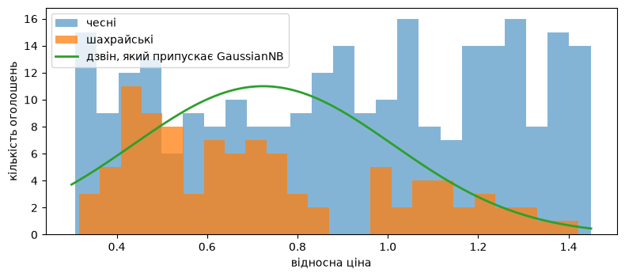

```
два згустки шахрайства по осі ціни, а модель має право лише на один дзвін
```

```python
import matplotlib.pyplot as plt

ціна_шахрайських = ознаки_навч[мітки_навч == 1, 0]
ціна_чесних = ознаки_навч[мітки_навч == 0, 0]

фігура, вісь = plt.subplots(figsize=(8, 3.6))
вісь.hist(ціна_чесних, bins=24, alpha=0.55, label="чесні")
вісь.hist(ціна_шахрайських, bins=24, alpha=0.75, label="шахрайські")

# крива, яку гаусів Баєс намалював для шахрайського класу
сітка_цін = np.linspace(0.30, 1.45, 300)
середнє = гаусів.theta_[1, 0]
розкид = np.sqrt(гаусів.var_[1, 0])
щільність = np.exp(-(сітка_цін - середнє) ** 2 / (2 * розкид ** 2)) / (розкид * np.sqrt(2 * np.pi))
# масштабуємо щільність під висоту гістограми, щоб форми можна було порівняти очима
висота, _ = np.histogram(ціна_шахрайських, bins=24)
вісь.plot(сітка_цін, щільність * висота.max() / щільність.max(),
          linewidth=2, label="дзвін, який припускає GaussianNB")

вісь.set_xlabel("відносна ціна")
вісь.set_ylabel("кількість оголошень")
вісь.legend()
фігура.tight_layout()
plt.show()

print("два згустки шахрайства по осі ціни, а модель має право лише на один дзвін")
```

Ось і відповідь. Дешеві приманки дають один горб, «преміум»-приманки — другий, а гаусів Баєс розтягує між ними єдиний дзвін і неминуче мажe. kNN нічого не припускає про форму й тому обводить обидві області окремо.

Це не поразка методу, а точний портрет його припущення: наївний Баєс завжди швидший і компактніший, а програє рівно там, де його припущення розходиться з даними.

## Завдання

### 🟢 Рівень 1

Візьми з архіву розділу 1 оголошення **«Гарантія, є чек, торг»** і порахуй для нього дві оцінки при `alpha = 1`. Вирок передбач до обчислення, а потім перевір.

**Зроблено, якщо** твоє число збігається з `MultinomialNB(alpha=1)` за `np.isclose`, і ти одним реченням пояснив, чому саме це оголошення виходить настільки чесним.

### 🟡 Рівень 2

Побудуй графік `P(шахрайство | текст)` для оголошення `["терміново", "передоплата", "дешево", "чек"]` при `alpha` від 0 до 5 (крок 0.05). Познач на ньому лінію 50%.

**Зроблено, якщо** на графіку видно, що крива стартує з нуля, перетинає 50% і далі виположується; у тексті названо, при якому приблизно `alpha` відбувається перетин і що станеться з кривою, якщо `alpha` зробити дуже великим.

### 🔴 Рівень 3

Напиши власний клас із методами `навчити(X, y)` і `передбачити_ймовірності(X)`, який повторює `MultinomialNB` — зі згладжуванням і повністю в логарифмах, без жодного множення ймовірностей.

**Зроблено, якщо** проходить перевірка `np.allclose(твої_ймовірності, MultinomialNB(alpha=1).fit(X, y).predict_proba(X))` на всіх ста оголошеннях архіву, і твій код не містить жодного множення двох ймовірностей — лише додавання логарифмів.